# rctd-py Tutorial

**GPU-accelerated spatial transcriptomics deconvolution using RCTD (Robust Cell Type Decomposition).**

This notebook demonstrates an end-to-end RCTD workflow using synthetic data: generating a single-cell reference, building a `Reference` object, running RCTD in all three modes (full, doublet, multi), interpreting results, and validating against known ground-truth weights.

## Installation

```
pip install rctd-py   # CPU (works everywhere; GPU auto-detected if CUDA available)
```

```python
import time
import numpy as np
import matplotlib.pyplot as plt
import matplotlib.patches as mpatches
import anndata
from rctd import Reference, RCTD, run_rctd, RCTDConfig
```

## 1. Create Synthetic Data

We generate synthetic single-cell reference data and spatial (pixel-level) data for this tutorial. The reference contains 5 simulated cell types with marker genes, and the spatial data contains pixels that are mixtures of those cell types with known ground-truth weights (so we can validate later).

```python
def make_synthetic_reference(n_genes=200, n_cells=500, n_types=5, seed=42):
    rng = np.random.default_rng(seed)
    cell_type_names = [f"Type_{i}" for i in range(n_types)]
    cells_per_type = n_cells // n_types
    profiles = rng.exponential(0.001, size=(n_genes, n_types))
    markers_per_type = n_genes // n_types
    for k in range(n_types):
        start = k * markers_per_type
        end = start + markers_per_type
        profiles[start:end, k] *= 10.0
    profiles = profiles / profiles.sum(axis=0, keepdims=True)
    counts = np.zeros((n_genes, n_cells), dtype=np.float32)
    cell_types = []
    nUMI = rng.integers(500, 5000, size=n_cells).astype(np.float32)
    for k in range(n_types):
        for c in range(cells_per_type):
            idx = k * cells_per_type + c
            lam = profiles[:, k] * nUMI[idx]
            counts[:, idx] = rng.poisson(lam).astype(np.float32)
            cell_types.append(cell_type_names[k])
    adata = anndata.AnnData(
        X=counts.T,
        obs={"cell_type": cell_types},
    )
    adata.var_names = [f"Gene_{i}" for i in range(n_genes)]
    adata.obs_names = [f"Cell_{i}" for i in range(n_cells)]
    return adata, profiles, cell_type_names

ref_adata, true_profiles, cell_type_names = make_synthetic_reference()
print(f"Reference: {ref_adata.n_obs} cells x {ref_adata.n_vars} genes")
print(f"Cell types: {cell_type_names}")
```

```
Reference: 500 cells x 200 genes
Cell types: ['Type_0', 'Type_1', 'Type_2', 'Type_3', 'Type_4']
```

```python
def make_synthetic_spatial(profiles, n_pixels=200, n_types=5, seed=123):
    rng = np.random.default_rng(seed)
    n_genes = profiles.shape[0]
    raw_weights = rng.dirichlet(np.ones(n_types) * 0.5, size=n_pixels).astype(np.float32)
    nUMI = rng.integers(200, 3000, size=n_pixels).astype(np.float32)
    counts = np.zeros((n_genes, n_pixels), dtype=np.float32)
    for i in range(n_pixels):
        lam = (profiles @ raw_weights[i]) * nUMI[i]
        counts[:, i] = rng.poisson(lam).astype(np.float32)
    coords = rng.uniform(0, 100, size=(n_pixels, 2))
    adata = anndata.AnnData(
        X=counts.T,
        obs={"x": coords[:, 0], "y": coords[:, 1]},
    )
    adata.var_names = [f"Gene_{i}" for i in range(n_genes)]
    adata.obs_names = [f"Pixel_{i}" for i in range(n_pixels)]
    return adata, raw_weights

spatial_adata, true_weights = make_synthetic_spatial(true_profiles)
print(f"Spatial: {spatial_adata.n_obs} pixels x {spatial_adata.n_vars} genes")
```

```
Spatial: 200 pixels x 200 genes
```

## 2. Build Reference

The `Reference` class takes a single-cell `AnnData` object and computes per-type expression profiles (mean UMI-normalized counts) used as the RCTD reference. Specify the `cell_type_col` parameter to point to the column in `.obs` that holds cell type labels.

```python
reference = Reference(ref_adata, cell_type_col="cell_type")
print(f"Reference profiles: {reference.profiles.shape}")
print(f"Cell types: {reference.cell_type_names}")
```

```
Reference profiles: (200, 5)
Cell types: ['Type_0', 'Type_1', 'Type_2', 'Type_3', 'Type_4']
```

## 3. Run RCTD

RCTD supports three deconvolution modes. Choose the mode that best fits your tissue and technology:

| Mode | Description |
| --- | --- |
| `full` | Estimates continuous weights for all cell types simultaneously |
| `doublet` | Classifies each pixel as singlet or doublet, assigns 1-2 types |
| `multi` | Greedy forward selection of up to `MAX_MULTI_TYPES` cell types |

### Full Mode

Full mode estimates a continuous weight vector over all cell types for every spatial pixel. This is the most flexible mode and is recommended when spots or pixels may contain mixtures of more than two cell types (e.g. Visium).

```python
t0 = time.time()
result_full = run_rctd(spatial_adata, reference, mode="full")
t_full = time.time() - t0
print(f"Full mode: {t_full:.1f}s")
print(f"Weights shape: {result_full.weights.shape}")
print(f"Converged: {result_full.converged.sum()}/{len(result_full.converged)} pixels")
```

```
Gene lists: bulk=196, reg=185 (from 200 common)
Fitting bulk platform effects...
```

```
Using 185 DE genes for pixel-level fitting
```

```
Estimating sigma...
```

```
Chosen sigma: 0.21 (2.8s)
Running in full mode...
```

```
Full mode: 6.8s
Weights shape: (200, 5)
Converged: 200/200 pixels
```

### Doublet Mode

Doublet mode classifies each pixel as a singlet (one dominant cell type) or doublet (two cell types). It returns `first_type` and `second_type` indices, as well as a `spot_class` label (`"singlet"`, `"doublet_certain"`, `"doublet_uncertain"`, or `"reject"`).

```python
t0 = time.time()
result_doublet = run_rctd(spatial_adata, reference, mode="doublet")
t_doublet = time.time() - t0
print(f"Doublet mode: {t_doublet:.1f}s")
classes, counts = np.unique(result_doublet.spot_class, return_counts=True)
class_labels = {1: 'singlet', 2: 'doublet_certain', 3: 'doublet_uncertain', 4: 'reject'}
for cl, ct in zip(classes, counts):
    print(f"  {class_labels.get(cl, cl)}: {ct}")
```

```
Gene lists: bulk=196, reg=185 (from 200 common)
Fitting bulk platform effects...
Using 185 DE genes for pixel-level fitting
```

```
Estimating sigma...
```

```
Chosen sigma: 0.21 (1.7s)
Running in doublet mode...
```

```
Doublet mode: 10.3s
  singlet: 4
  doublet_certain: 185
  doublet_uncertain: 11
```

### Multi Mode

Multi mode performs greedy forward selection, adding cell types one at a time until adding another type no longer improves the fit. The maximum number of types per pixel is controlled by `RCTDConfig.MAX_MULTI_TYPES` (default: 4). This mode is a good middle ground between full and doublet.

```python
t0 = time.time()
result_multi = run_rctd(spatial_adata, reference, mode="multi")
t_multi = time.time() - t0
print(f"Multi mode: {t_multi:.1f}s")
print(f"Types per pixel: min={result_multi.n_types.min()}, max={result_multi.n_types.max()}")
```

```
Gene lists: bulk=196, reg=185 (from 200 common)
Fitting bulk platform effects...
Using 185 DE genes for pixel-level fitting
```

```
Estimating sigma...
```

```
Chosen sigma: 0.21 (2.3s)
Running in multi mode...
```

```
Multi mode: 23.9s
Types per pixel: min=1, max=4
```

## 4. Interpreting Results

```python
# Dominant cell type per pixel (full mode)
dominant_types = np.argmax(result_full.weights, axis=1)
dominant_names = [cell_type_names[i] for i in dominant_types]

# Weight statistics
print("Weight statistics per cell type:")
for i, name in enumerate(cell_type_names):
    w = result_full.weights[:, i]
    print(f"  {name}: mean={w.mean():.3f}, max={w.max():.3f}")
```

```
Weight statistics per cell type:
  Type_0: mean=0.210, max=0.886
  Type_1: mean=0.192, max=0.763
  Type_2: mean=0.191, max=0.930
  Type_3: mean=0.210, max=0.914
  Type_4: mean=0.177, max=0.940
```

## 5. Visualization

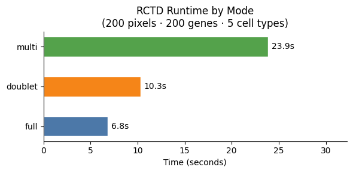

```python
# --- Plot 1: Runtime comparison ---
fig, ax = plt.subplots(figsize=(6, 3))
modes = ["full", "doublet", "multi"]
times = [t_full, t_doublet, t_multi]
colors = ["#4C78A8", "#F58518", "#54A24B"]
bars = ax.barh(modes, times, color=colors, edgecolor="white", height=0.5)
ax.bar_label(bars, fmt="%.1fs", padding=4, fontsize=10)
ax.set_xlabel("Time (seconds)")
ax.set_title("RCTD Runtime by Mode\n(200 pixels · 200 genes · 5 cell types)")
ax.set_xlim(0, max(times) * 1.35)
ax.spines[["top", "right"]].set_visible(False)
plt.tight_layout()
plt.show()
```

### Spatial maps

Each panel shows the 200 synthetic pixels colored by the RCTD result for that mode.

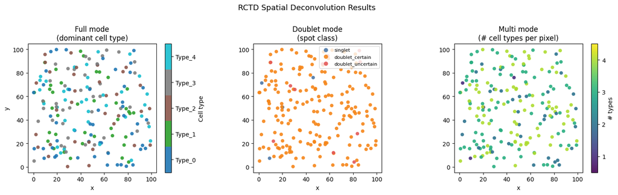

```python
# --- Plot 2: Full mode — dominant cell type per pixel ---
dominant_types = np.argmax(result_full.weights, axis=1)
cmap = plt.cm.get_cmap("tab10", len(cell_type_names))

fig, axes = plt.subplots(1, 3, figsize=(15, 4.5))

sc = axes[0].scatter(
    spatial_adata.obs["x"], spatial_adata.obs["y"],
    c=dominant_types, cmap=cmap, vmin=-0.5, vmax=len(cell_type_names) - 0.5,
    s=35, alpha=0.9, edgecolors="none"
)
axes[0].set_title("Full mode\n(dominant cell type)")
axes[0].set_aspect("equal"); axes[0].set_xlabel("x"); axes[0].set_ylabel("y")
plt.colorbar(sc, ax=axes[0], ticks=range(len(cell_type_names)),
             label="Cell type").set_ticklabels(cell_type_names)

# --- Doublet mode — spot class ---
class_labels = {1: "singlet", 2: "doublet_certain", 3: "doublet_uncertain", 4: "reject"}
class_colors = {1: "#4C78A8", 2: "#F58518", 3: "#E45756", 4: "#888888"}
spot_colors = [class_colors.get(int(s), "#aaa") for s in result_doublet.spot_class]
for cls, color in class_colors.items():
    mask = result_doublet.spot_class == cls
    if mask.any():
        axes[1].scatter(
            spatial_adata.obs["x"][mask], spatial_adata.obs["y"][mask],
            c=color, s=35, alpha=0.9, edgecolors="none",
            label=class_labels[cls]
        )
axes[1].set_title("Doublet mode\n(spot class)")
axes[1].set_aspect("equal"); axes[1].set_xlabel("x")
axes[1].legend(fontsize=8, markerscale=1.2, loc="upper right")

# --- Multi mode — number of types per pixel ---
n_types = result_multi.n_types
sc2 = axes[2].scatter(
    spatial_adata.obs["x"], spatial_adata.obs["y"],
    c=n_types, cmap="viridis", vmin=0.5, vmax=4.5,
    s=35, alpha=0.9, edgecolors="none"
)
axes[2].set_title("Multi mode\n(# cell types per pixel)")
axes[2].set_aspect("equal"); axes[2].set_xlabel("x")
plt.colorbar(sc2, ax=axes[2], ticks=[1, 2, 3, 4], label="# types")

plt.suptitle("RCTD Spatial Deconvolution Results", fontsize=13, y=1.01)
plt.tight_layout()
plt.show()
```

### Weight distributions

Per-type weight distributions from full mode across all pixels.

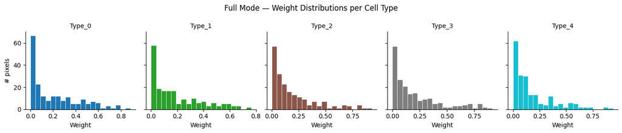

```python
# --- Plot 3: Per-type weight distributions (full mode) ---
fig, axes = plt.subplots(1, len(cell_type_names), figsize=(14, 3), sharey=True)
colors = plt.cm.tab10(np.linspace(0, 1, len(cell_type_names)))

for k, (name, color) in enumerate(zip(cell_type_names, colors)):
    axes[k].hist(result_full.weights[:, k], bins=20, color=color,
                 edgecolor="white", linewidth=0.5)
    axes[k].set_title(name, fontsize=10)
    axes[k].set_xlabel("Weight")
    axes[k].spines[["top", "right"]].set_visible(False)

axes[0].set_ylabel("# pixels")
plt.suptitle("Full Mode — Weight Distributions per Cell Type", fontsize=12)
plt.tight_layout()
plt.show()
```

## 6. Validation Against Ground Truth

Because we generated synthetic data with known mixing weights, we can directly compare the RCTD-recovered weights to the true weights using per-pixel Pearson correlation.

```python
# Normalize recovered weights to sum to 1
w_norm = result_full.weights / result_full.weights.sum(axis=1, keepdims=True)

# Per-pixel Pearson correlation with true weights
correlations = np.array([
    np.corrcoef(w_norm[i], true_weights[i])[0, 1]
    for i in range(len(true_weights))
])
print(f"Per-pixel weight correlation with ground truth:")
print(f"  Mean:   {np.nanmean(correlations):.4f}")
print(f"  Median: {np.nanmedian(correlations):.4f}")
print(f"  > 0.8:  {(correlations > 0.8).sum()}/{len(correlations)}")
```

```
Per-pixel weight correlation with ground truth:
  Mean:   0.9952
  Median: 0.9989
  > 0.8:  200/200
```

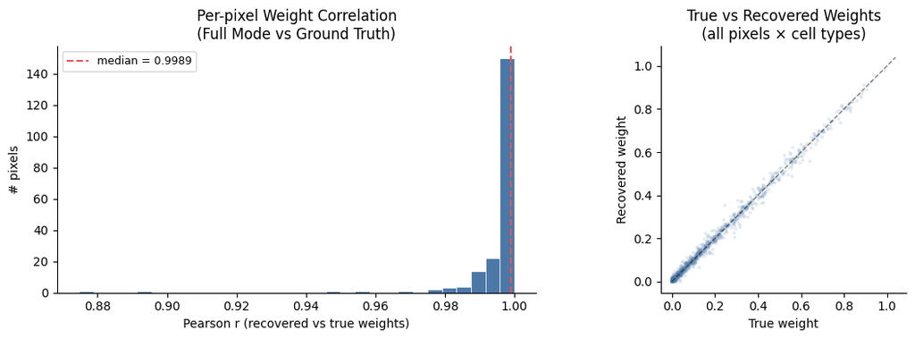

```python
# --- Plot 4: Correlation histogram + scatter (recovered vs true weights) ---
fig, axes = plt.subplots(1, 2, figsize=(12, 4))

# Histogram of per-pixel correlations
axes[0].hist(correlations, bins=30, color="#4C78A8", edgecolor="white", linewidth=0.5)
axes[0].axvline(np.nanmedian(correlations), color="#E45756", lw=1.5,
                linestyle="--", label=f"median = {np.nanmedian(correlations):.4f}")
axes[0].set_xlabel("Pearson r (recovered vs true weights)")
axes[0].set_ylabel("# pixels")
axes[0].set_title("Per-pixel Weight Correlation\n(Full Mode vs Ground Truth)")
axes[0].legend(fontsize=9)
axes[0].spines[["top", "right"]].set_visible(False)

# Scatter: true vs recovered (flattened across all pixels × types)
true_flat = true_weights.ravel()
rec_flat = w_norm.ravel()
axes[1].scatter(true_flat, rec_flat, alpha=0.15, s=8, color="#4C78A8", edgecolors="none")
lim = max(true_flat.max(), rec_flat.max()) * 1.05
axes[1].plot([0, lim], [0, lim], "k--", lw=1, alpha=0.5)
axes[1].set_xlabel("True weight")
axes[1].set_ylabel("Recovered weight")
axes[1].set_title("True vs Recovered Weights\n(all pixels × cell types)")
axes[1].set_aspect("equal")
axes[1].spines[["top", "right"]].set_visible(False)

plt.tight_layout()
plt.show()
```

## Configuration

`RCTDConfig` controls all algorithm hyperparameters. Key parameters:

| Parameter | Default | Description |
| --- | --- | --- |
| `UMI_min` | 100 | Minimum UMI count to include a pixel |
| `N_fit` | 1000 | Number of pixels used to estimate the overdispersion parameter sigma |
| `MAX_MULTI_TYPES` | 4 | Maximum cell types per pixel in multi mode |
| `max_iter` | 50 | Maximum IRWLS (iteratively reweighted least squares) iterations |
| `doublet_mode_alpha` | 0.01 | Regularization strength in doublet mode |

The `batch_size` argument to `run_rctd` controls how many pixels are processed per GPU kernel launch. Larger values use more VRAM but may be faster.

```python
# Custom configuration
config = RCTDConfig(
    UMI_min=100,          # Minimum UMI per pixel
    N_fit=1000,           # Pixels for sigma estimation
    MAX_MULTI_TYPES=4,    # Max types in multi mode
    max_iter=50,          # IRWLS iterations
)

# Run with custom config and batch size
result = run_rctd(spatial_adata, reference, mode="full", config=config, batch_size=5000)
```

```
Gene lists: bulk=196, reg=185 (from 200 common)
Fitting bulk platform effects...
Using 185 DE genes for pixel-level fitting
```

```
Estimating sigma...
```

```
Chosen sigma: 0.21 (2.5s)
Running in full mode...
```